# Exploration Template

### Summary

Inside this document you will find all exploratory analysis and explanatory questions with regards to dataframe. The first part is dedicated to explore some general aspects of data and find some hidden patterns. Then a deeper analysis is performed in order to plot graphs to explain trends and observations. At last final remarks is posed and a conclusion of our entire analysis is achieved.

### Introduction

This project is the final part of the Udacity Data Analyst Nano Degree Program. An exploratory data analysis was built on a data set from Prosper, which is America’s first marketplace lending platform, with many billion in funded loans. This data set contains about 114k (113,937) loans with 81 variables on each loan, e.g., loan amount, borrower rate (or interest rate), current loan status, borrower income, borrower employment status, estimated loss, borrower state and many other usefull stuff.

### Objectives

The aim of this project is to analyze how financial data and personal data from borrowers and lenders can affect the loan status and to get some insights about the relationships among multiple variables using statistics and data visualizations.

1. Introduction
2. Univariate Plots Section and Analysis
3. Bivariate Plots Section and Analysis
4. Multivariate Plots Section and Analysis
5. Final Remarks

## Univariate Exploration

In this part univariate exploration will be performed in order to check general information of the dataframe.

### 1. Loan count per Quarter

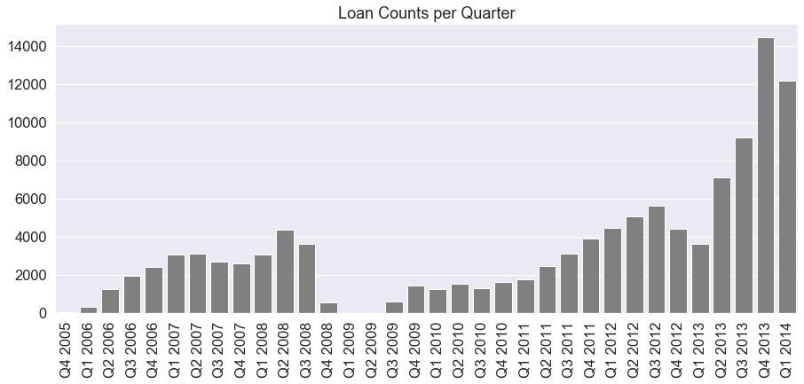

```python
#Plotting Loan  per quarter
sns.set(style="darkgrid")
sns.set_context("notebook", font_scale=1.5, rc={"lines.linewidth": 2.5})
ax = plt.subplots(figsize=(15, 6))
plt.xticks(rotation='vertical')
ax = sns.countplot(x = "LoanOriginationQuarter",
                   data = df,
                   color = "gray",
                   order = ['Q4 2005',
                            'Q1 2006',
                            'Q2 2006',
                            'Q3 2006',
                            'Q4 2006',
                            'Q1 2007',
                            'Q2 2007',
                            'Q3 2007',
                            'Q4 2007',
                            'Q1 2008',
                            'Q2 2008',
                            'Q3 2008',
                            'Q4 2008',
                            'Q1 2009',
                            'Q2 2009',
                            'Q3 2009',
                            'Q4 2009',
                            'Q1 2010',
                            'Q2 2010',
                            'Q3 2010',
                            'Q4 2010',
                            'Q1 2011',
                            'Q2 2011',
                            'Q3 2011',
                            'Q4 2011',
                            'Q1 2012',
                            'Q2 2012',
                            'Q3 2012',
                            'Q4 2012',
                            'Q1 2013',
                            'Q2 2013',
                            'Q3 2013',
                            'Q4 2013',
                            'Q1 2014',])
ax.set_ylabel('')
ax.set_xlabel('')
ax.set_title('Loan Counts per Quarter');
```

**Insight:** It is possible to conclude in this plot that most of the loans ocurried during 2012, 2013 and 2014 probably after a brief recovery from the financial crisis that hit USA during 2007 and 2008.

### 2. Loan counts per Status

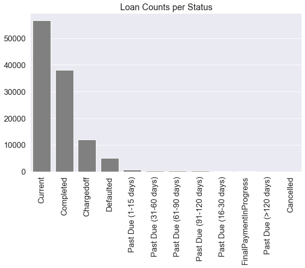

```python
#Plotting Loan status
sns.set(style="darkgrid")
sns.set_context("notebook", font_scale=1.5, rc={"lines.linewidth": 2.5})
ax = plt.subplots(figsize=(10, 6))
plt.xticks(rotation='vertical')
ax = sns.countplot(x = "LoanStatus",
                   data = df,
                   color = "gray",
                   order = df['LoanStatus'].value_counts().index)
ax.set_ylabel('')
ax.set_xlabel('')
ax.set_title('Loan Counts per Status');
```

**Insight:** The moment we perform this analysis most of the loans are with "current" status, followed by "completed". Important notice that a few are pending ("past due") or either "canceled".

### 3. Loan counts per Prosper Rating

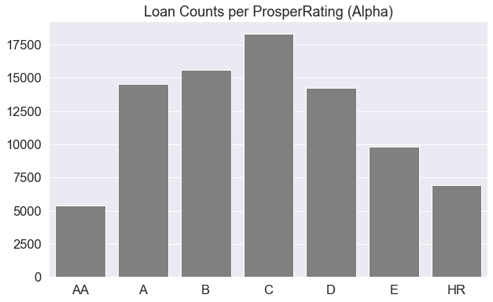

```python
#Plotting Proper risk rating status
sns.set(style="darkgrid")
sns.set_context("notebook", font_scale=1.5, rc={"lines.linewidth": 2.5})
ax = plt.subplots(figsize=(10, 6))
ax = sns.countplot(x = "ProsperRating (Alpha)",
                   data = df,
                   color = "gray",
                   order = ['AA', 'A', 'B', 'C', 'D', 'E', 'HR'])
ax.set_ylabel('')
ax.set_xlabel('')
ax.set_title('Loan Counts per ProsperRating (Alpha)');
```

**Insight:** The above plot shows that prosper rating follow a pattern similar do normal distribution in which the probability is high for a loan to be mid-rated (B-C-D) as well as low for a high/low-rated (AA-HR).

### 4. Loan counts per Prosper Score

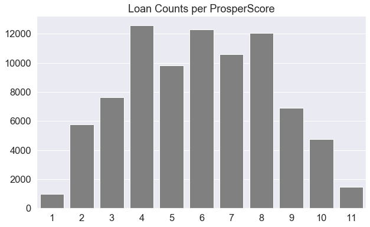

```python
#Plotting Proper Score
sns.set(style="darkgrid")
sns.set_context("notebook", font_scale=1.5, rc={"lines.linewidth": 2.5})
ax = plt.subplots(figsize=(10, 6))
ax = sns.countplot(x = "ProsperScore",
                   data = df,
                   color = "gray",
                   order = [1, 2, 3, 4, 5, 6, 7, 8, 9, 10, 11])
ax.set_ylabel('')
ax.set_xlabel('')
ax.set_title('Loan Counts per ProsperScore');
```

### 5. Loan counts per State

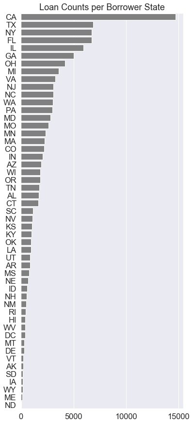

```python
#Plotting Loan counts per State
sns.set(style="darkgrid")
sns.set_context("notebook", font_scale=1.5, rc={"lines.linewidth": 2.5})
ax = plt.subplots(figsize=(6, 15))
ax = sns.countplot(y = "BorrowerState",
                   data = df,
                   color = "gray",
                   order = df['BorrowerState'].value_counts().index)
ax.set_ylabel('')
ax.set_xlabel('')
ax.set_title('Loan Counts per Borrower State');
```

**Insight:** California, Texas, New York and Florida are the states that have more loans registered.

### 6. Loan count per Income Rate

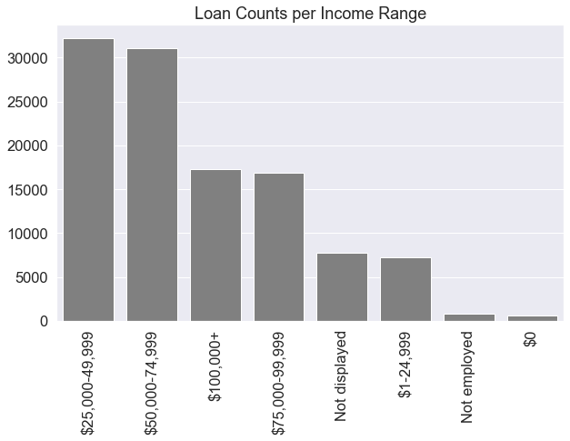

```python
#Plotting Loan counts per State
sns.set(style="darkgrid")
sns.set_context("notebook", font_scale=1.5, rc={"lines.linewidth": 2.5})
ax = plt.subplots(figsize=(10, 6))
plt.xticks(rotation='vertical')
ax = sns.countplot(x = "IncomeRange",
                   data = df,
                   color = "gray",
                   order = df['IncomeRange'].value_counts().index)
ax.set_ylabel('')
ax.set_xlabel('')
ax.set_title('Loan Counts per Income Range');
```

**Insight:** The vast majority of people has an income range of about 25k up to 50k, followed closely by the range 50k up to 75k per year. Then we have a second group of richer people with more 75k per year. At last, the poorer are still a minority with less than 25k per year.

## Bivariate Exploration

In this part bivariate exploration will be performed in order to check general information of the dataframe.

### 1. Borrower Rate Time Series

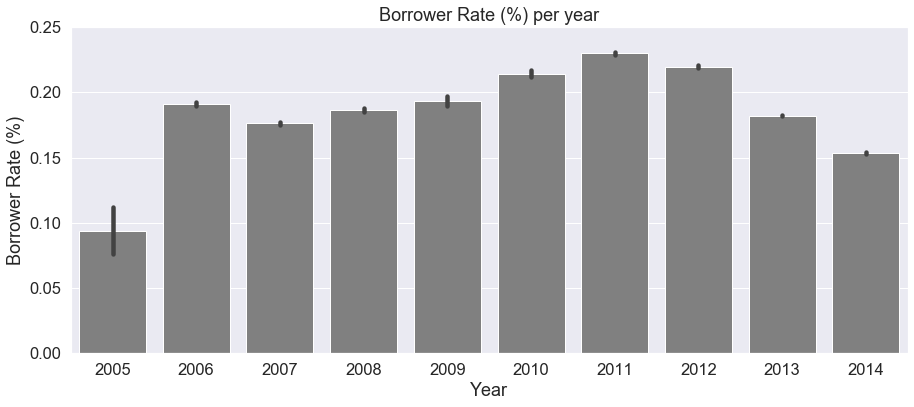

```python
#Plot Borrower rate time series
sns.set(style="darkgrid")
sns.set_context("notebook", font_scale=1.5, rc={"lines.linewidth": 2.5})
ax = plt.subplots(figsize=(15, 6))
ax = sns.barplot(data = df,
                 x = "year",
                 y= "BorrowerRate",
                 color = "gray")
ax.set_ylabel('Borrower Rate (%)')
ax.set_xlabel('Year')
ax.set_ylim(0,0.25)
ax.set_title('Borrower Rate (%) per year');
```

### 2. Debt to Income Ration vs Prosper Rating (Alpha)

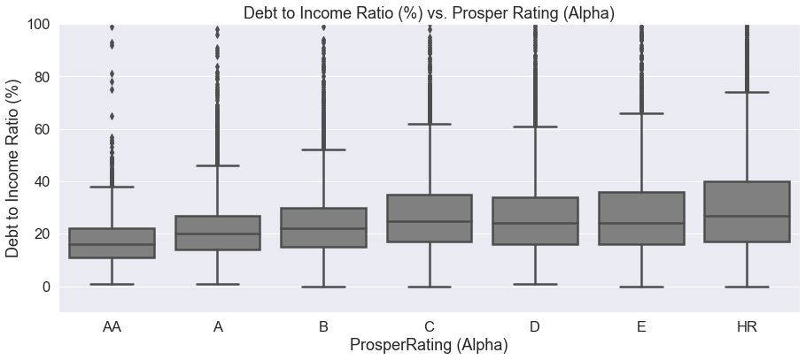

```python
sns.set(style="darkgrid")
sns.set_context("notebook", font_scale=1.5, rc={"lines.linewidth": 2.5})
ax = plt.subplots(figsize=(15, 6))
ax = sns.boxplot(data = df_dr,
                 x = "ProsperRating (Alpha)",
                 y = "DebtToIncomeRatio",
                 color = "gray",
                 order = ['AA', 'A', 'B', 'C', 'D', 'E', 'HR']);
ax.set_ylabel('Debt to Income Ratio (%)')
ax.set_xlabel('ProsperRating (Alpha)')
ax.set_ylim(-10,100)
ax.set_title('Debt to Income Ratio (%) vs. Prosper Rating (Alpha)');
```

**Insight:** By analyizing this box chart we can see that higher ratings can be associated with a lower debt to income ratio, so that poorer ratings (e.g. E and HR) tends to present a higher debt ratio with a wide spread.

### 3. Estimated Loss vs Prosper Rating (Alpha)

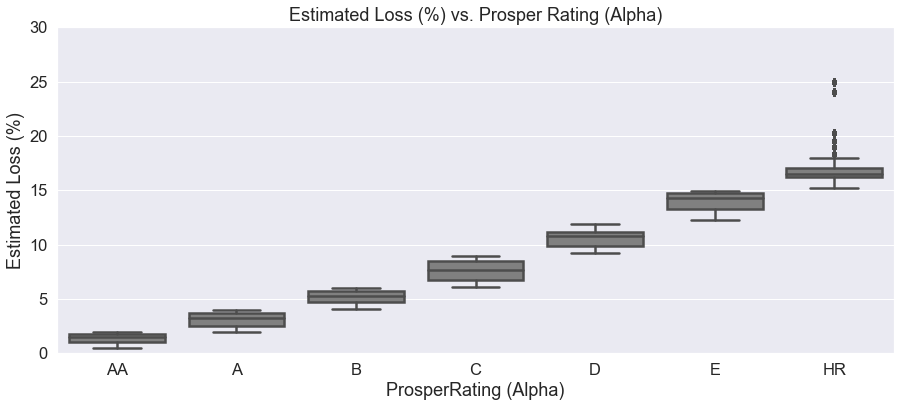

```python
sns.set(style="darkgrid")
sns.set_context("notebook", font_scale=1.5, rc={"lines.linewidth": 2.5})
ax = plt.subplots(figsize=(15, 6))
ax = sns.boxplot(data = df_el,
                 x = "ProsperRating (Alpha)",
                 y = "EstimatedLoss",
                 color = "gray",
                 order = ['AA', 'A', 'B', 'C', 'D', 'E', 'HR']);
ax.set_ylabel('Estimated Loss (%)')
ax.set_xlabel('ProsperRating (Alpha)')
ax.set_ylim(0,30)
ax.set_title('Estimated Loss (%) vs. Prosper Rating (Alpha)');
```

**Insight:** By analyizing this box chart we can see that lower ratings can be associated with higher losses, near 17 percent, and this also presents risky operations. Moreover, high ratings presents a natural lower risk so that its loss is very reduced, near zero.

### Multivariate Exploration

In this part multivariate exploration will be performed in order to check general information of the dataframe.

### 1. Debt to income ration vs Time series vs ProsperRating (Alpha)

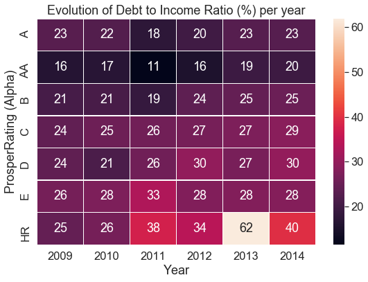

```python
#Plot heatmap for Debt to income ratio per year
sns.set(style="darkgrid")
sns.set_context("notebook", font_scale=1.5, rc={"lines.linewidth": 2.5})
ax = plt.subplots(figsize=(9, 6))
ax = sns.heatmap(df_hm1, annot=True, linewidths=.5)
ax.set_ylabel('ProsperRating (Alpha)')
ax.set_xlabel('Year')
ax.set_title('Evolution of Debt to Income Ratio (%) per year');
```

**Insight:** The heatmap above shows the evolution of debt to income ratio along the year, we can check that people with higher ratings (A and AA) presented a slightly to none increase in debt ratio. However, people with lower ratings presented an increase in debt ratio along the years.

### 2. Estimated Loss vs Time series vs Prosper Ratings (Alpha)

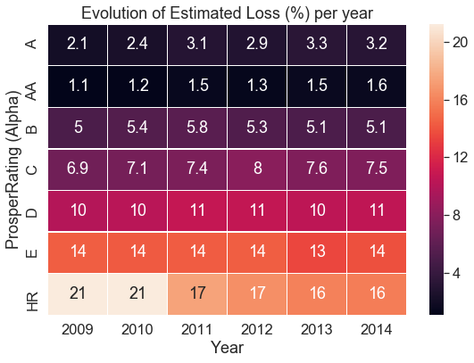

```python
#Plot heatmap for estimated loss per year
sns.set(style="darkgrid")
sns.set_context("notebook", font_scale=1.5, rc={"lines.linewidth": 2.5})
ax = plt.subplots(figsize=(9, 6))
ax = sns.heatmap(df_hm2, annot=True, linewidths=.5)
ax.set_ylabel('ProsperRating (Alpha)')
ax.set_xlabel('Year')
ax.set_title('Evolution of Estimated Loss (%) per year');
```

**Insight:** The heatmap above shows the evolution of estimated loss along the years, we can check that people with higher ratings (A and AA) presented a few losses up to 3 percent. However, people with lower ratings presented a loss above average up to 20 percent. Important notice that for HR rating presented a net recovery of 5 percent to 16 from 21 percent (2009 to 2014).

### 3. ProsperRating (Alpha) vs counts vs IsBorrowerHomeOwner

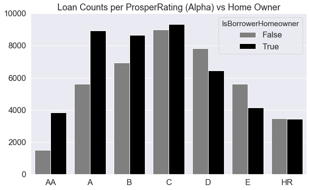

```python
#Plotting Proper risk rating status
sns.set(style="darkgrid")
sns.set_context("notebook", font_scale=1.5, rc={"lines.linewidth": 2.5})
ax = plt.subplots(figsize=(10, 6))
ax = sns.countplot(x = "ProsperRating (Alpha)",
                   data = df,
                   palette = ["gray", "black"],
                   order = ['AA', 'A', 'B', 'C', 'D', 'E', 'HR'],
                   hue = "IsBorrowerHomeowner")
ax.set_ylabel('')
ax.set_ylim(0,10000)
ax.set_xlabel('')
ax.set_title('Loan Counts per ProsperRating (Alpha) vs Home Owner');
```

**Insight:** The above barplot shows the impact of being an home owner with regard to its prosper rating. While people with higher ratings A-AA is a home owner, the is scenario is inverted for lower ratings D-E-HR where most of people are not home owner.

### Final Remarks

The Prosper data frame is a rich platform to find usefull information with regards to how financial institutions control who gets the money they lend, who gets priority, who gets better conditions payment, who are better client and so on. The data is well structured and litle to none data wrangling were needed. The dataframe consists of almost 114k rows and 81 columns with all kind of data from state, loan amount, home owner, etc.

I chose some variables in the universe of this dataframe in order to analyze its relationship, but there's much more work to be done on this plataform as well as built new links between political scenarios and macroeconomy of USA during 2005 up to 2014, e.g., finacial crisis of 08', Obama's election, stocks exchange around the world, terrorism, etc.

By analyzing loan count along the years, we can speculate that it was strong affected by the financial crisis of 08', and while USA begins its economical recovery efforts for the next years so the loan count was increased. We could also see that rich states such as: California, Texas, New York and Florida were more proeminent resulting in a higher loan count along this timeseries.

Most of the loans were conceded to mid prosper ratings taking into account both Alpha (AA-A-B-C-D-HR) and Numeric (1 to 11). Moreover the average wage of a typical borrower were about 25k up to 75k, with a lower count for richer and poorer than this range.

By analyzing the each rating individually we can check that higher rating presented a lower debt to income ration as well as lower loss while lower ratings presented higher debt to income ratio and higher losses in the same period. At last, owning a house can be related to higher ratings and lower payment risks.